# Projet - SY09

Détection de fraude à la carte bancaire

BOURGEON Théodore, HAIFEI Zhang, TARDIO Iker

# Introduction

## Contexte

La reconnaissance de fraude à la carte de crédit est important pour les orgnaismes bancaires pour éviter à leurs clients de se faire facturer des objects qu’ils n’ont pas acheté.

## Contenu

Le dataset contient des transactions effectuées par des cartes bancaires en Septembre 2013 pendant 2 jours par des détenteurs européens. Le dataset est très déséquilibré : la classe des fraudes représente seulement 0.172% des observations.

Il contient seuleument **les 28 premières composantes principales résultant d’une ACP** pour des raisons de confidentialitée ainsi que :

- **Time** contient le nombre de secondes écoulées entre chaque transaction et la première du dataset.
- **Amount** est le montant de la transaction, il peut etre utilisé pour un apprentissage sensible aux coûts et dépendant de l’exemple (example-dependant cost-senstive learning).
- **Class** est la varibale de classe, 1 correspond à un fraudeur, 0 sinon.

# Analyse

## Analyse exploratoire

```r
data <- read.csv("data/creditcard.csv", header = TRUE)
```

```r
head(data)
```

|  | Time | V1 | V2 | V3 | V4 | V5 | V6 | V7 | V8 | V9 | V10 | V11 | V12 | V13 | V14 | V15 | V16 | V17 | V18 | V19 | V20 | V21 | V22 | V23 | V24 | V25 | V26 | V27 | V28 | … |
| --- | --- | --- | --- | --- | --- | --- | --- | --- | --- | --- | --- | --- | --- | --- | --- | --- | --- | --- | --- | --- | --- | --- | --- | --- | --- | --- | --- | --- | --- | --- |
| 1 | 0 | -1.3598071 | -0.07278117 | 2.5363467 | 1.3781552 | -0.33832077 | 0.46238778 | 0.23959855 | 0.09869790 | 0.3637870 | 0.09079417 | -0.5515995 | -0.61780086 | -0.9913898 | -0.3111694 | 1.4681770 | -0.4704005 | 0.20797124 | 0.02579058 | 0.40399296 | 0.25141210 | -0.018306778 | 0.277837576 | -0.11047391 | 0.06692807 | 0.1285394 | -0.1891148 | 0.133558377 | -0.02105305 | … |
| 2 | 0 | 1.1918571 | 0.26615071 | 0.1664801 | 0.4481541 | 0.06001765 | -0.08236081 | -0.07880298 | 0.08510165 | -0.2554251 | -0.16697441 | 1.6127267 | 1.06523531 | 0.4890950 | -0.1437723 | 0.6355581 | 0.4639170 | -0.11480466 | -0.18336127 | -0.14578304 | -0.06908314 | -0.225775248 | -0.638671953 | 0.10128802 | -0.33984648 | 0.1671704 | 0.1258945 | -0.008983099 | 0.01472417 | … |
| 3 | 1 | -1.3583541 | -1.34016307 | 1.7732093 | 0.3797796 | -0.50319813 | 1.80049938 | 0.79146096 | 0.24767579 | -1.5146543 | 0.20764287 | 0.6245015 | 0.06608369 | 0.7172927 | -0.1659459 | 2.3458649 | -2.8900832 | 1.10996938 | -0.12135931 | -2.26185710 | 0.52497973 | 0.247998153 | 0.771679402 | 0.90941226 | -0.68928096 | -0.3276418 | -0.1390966 | -0.055352794 | -0.05975184 | … |
| 4 | 1 | -0.9662717 | -0.18522601 | 1.7929933 | -0.8632913 | -0.01030888 | 1.24720317 | 0.23760894 | 0.37743587 | -1.3870241 | -0.05495192 | -0.2264873 | 0.17822823 | 0.5077569 | -0.2879237 | -0.6314181 | -1.0596472 | -0.68409279 | 1.96577500 | -1.23262197 | -0.20803778 | -0.108300452 | 0.005273597 | -0.19032052 | -1.17557533 | 0.6473760 | -0.2219288 | 0.062722849 | 0.06145763 | … |
| 5 | 2 | -1.1582331 | 0.87773675 | 1.5487178 | 0.4030339 | -0.40719338 | 0.09592146 | 0.59294075 | -0.27053268 | 0.8177393 | 0.75307443 | -0.8228429 | 0.53819555 | 1.3458516 | -1.1196698 | 0.1751211 | -0.4514492 | -0.23703324 | -0.03819479 | 0.80348692 | 0.40854236 | -0.009430697 | 0.798278495 | -0.13745808 | 0.14126698 | -0.2060096 | 0.5022922 | 0.219422230 | 0.21515315 | … |
| 6 | 2 | -0.4259659 | 0.96052304 | 1.1411093 | -0.1682521 | 0.42098688 | -0.02972755 | 0.47620095 | 0.26031433 | -0.5686714 | -0.37140720 | 1.3412620 | 0.35989384 | -0.3580907 | -0.1371337 | 0.5176168 | 0.4017259 | -0.05813282 | 0.06865315 | -0.03319379 | 0.08496767 | -0.208253515 | -0.559824796 | -0.02639767 | -0.37142658 | -0.2327938 | 0.1059148 | 0.253844225 | 0.08108026 | … |

```r
dim(data)
```

```
[1] 284807     31
```

```r
data$Class <- as.factor(data$Class)
levels(data$Class)
```

```
[1] "0" "1"
```

On constate que notre jeu de donnée comporte 284 807 observations avec 30 prédicteurs et une colonne de classe.

```r
length(data$Class[data$Class == 0])
```

```
[1] 284315
```

```r
length(data$Class[data$Class == 1])
```

```
[1] 492
```

On possède 284 315 (99,82725 %) de non fraudeurs et 492 (0,1727486 %) observations de fraudeurs.

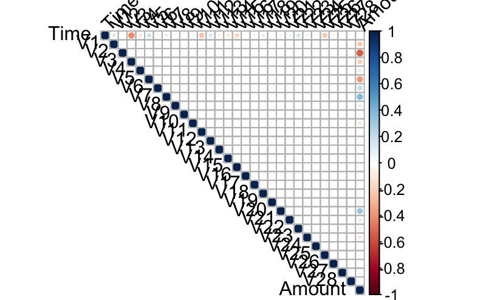

```r
# Correlation matrix
mcor<-cor(data[,-31])
corrplot::corrplot(mcor,type="upper",tl.col="black",tl.srt=45)
```

Les variables sont très peu, voir pas corrélées. On peut supposer que la variable amount le soit légèrement car elle dépend de caractéristiques amont de l’ACP. On vérifie ainsi que l’ACP à bien joué son role et décorélé le jeu de donnée dans ses 28 composantes principales.

Nous nous concentrerons dans un premier temps sur les données dont nous avons des informations, c’est à dire **Time** et **Amount** avant de regarder les informations propre à l’ACP.

## TIME

```r
summary(data$Time)
```

```
   Min. 1st Qu.  Median    Mean 3rd Qu.    Max.
      0   54202   84692   94814  139320  172792
```

Les données data$Time sont bien comprises entre 0 et 172792 pour la dernière transactions : cela correspond bien à deux jours de transactions.

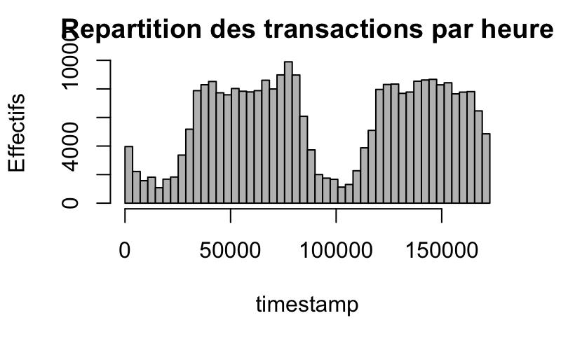

```r
hist(data$Time,main="Repartition des transactions par heure",xlab="timestamp",ylab="Effectifs", breaks=seq(0,172800, by=3600), col="grey")
```

La répartition des transactions semble correspondre à l’activité des utilisateur, on observe 6h creusent qui correspondent aux heures de nuit de l’union européenne en prenant en compte le décalage horaire.

Regardons si les fraudeurs respectent un pattern horaire pour leurs attaques.

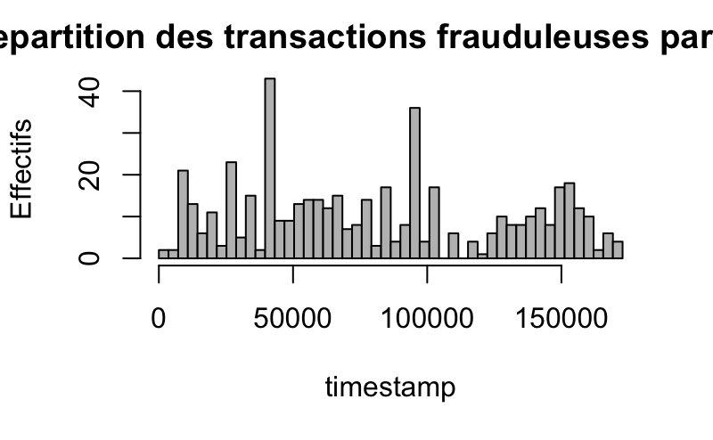

```r
hist(data$Time[data$Class == 1],main="Repartition des transactions frauduleuses par heure",xlab="timestamp",ylab="Effectifs", breaks=seq(0,172800, by=3600), col="grey")
```

Nous n’observons aucun modèle particulier. Dans ce cas nous pouvons supprimer ce predicteur dans nos modèles.

```r
data <- data[,-1]
```

## AMOUNT

```r
summary(data$Amount)
```

```
    Min.  1st Qu.   Median     Mean  3rd Qu.     Max.
    0.00     5.60    22.00    88.35    77.17 25691.16
```

Les transactions ont une moyenne de 88,35 euros et s’échelonnent de 0 à 25 000 euros.

On constate que le minimum de transaction est de 0.00 euros.

```r
data.frame(
    Nombre_transaction_0_euros = c("Total", "Valide", "Frauduleuse"),
    Value = c(sum(data$Amount == 0), sum(data$Amount[data$Class == 0] == 0), sum(data$Amount[data$Class == 1] == 0))
  )
```

| Nombre_transaction_0_euros | Value |
| --- | --- |
| Total | 1825 |
| Valide | 1798 |
| Frauduleuse | 27 |

Le dataset comprend 1825 transactions avec des montants nuls (1798 valides et 27 frauduleuses). Nous considérons ces données non pertinentes et les supprimons de notre jeu de donnée.

```r
dim(data)[1]
```

```
[1] 284807
```

```r
data <- data[data$Amount != 0,]
dim(data)[1]
```

```
[1] 282982
```

On passe alors de 284807 observations à 282982.

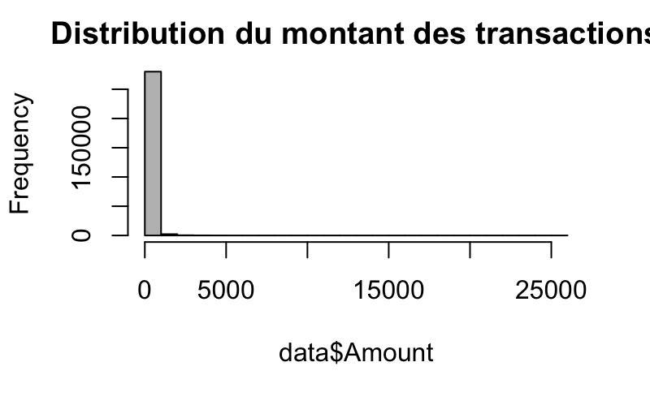

```r
hist(data$Amount,main="Distribution du montant des transactions", col="grey")
```

On constate qu’une majorité des transactions est à montant faible, ce qui nous invite à regarder la proportion de montant supérieur à 1000euros. En effet, nous recherchons un modèle généralisant au mieux nos données et préférons supprimer les outliers de notre dataset. Nous ferons attention à ce que cela ne comprenne pas trop de donnée frauduleuse (en effet nous n’en possédons peu). Notre modèle d’appliquera donc aux transactions d’un montant inférieur à 1000euros. Si celui-ce dépasse, un autre modèle devra s’appliquer (ou une action humaine de vérification).

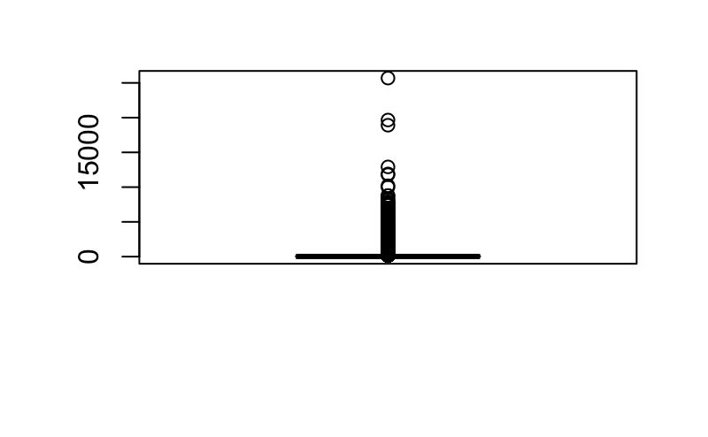

```r
boxplot(data$Amount)
```

```r
data.frame(
    Nombre_transaction_sup_1000_euros = c("Total", "Valide", "Frauduleuse"),
    Value = c(sum(data$Amount >= 1000), sum(data$Amount[data$Class == 0] >= 1000), sum(data$Amount[data$Class == 1] >= 1000))
  )
```

| Nombre_transaction_sup_1000_euros | Value |
| --- | --- |
| Total | 3069 |
| Valide | 3060 |
| Frauduleuse | 9 |

```r
dim(data)[1]
```

```
[1] 282982
```

```r
data <- data[data$Amount <= 1000,]
dim(data)[1]
```

```
[1] 280042
```

```r
dim(data[data$Class == 0,])[1]
```

```
[1] 279586
```

```r
dim(data[data$Class == 1,])[1]
```

```
[1] 456
```

Nous passons de 282982 observations à 280042 (456 frauduleuses et 279586 valides). L’explication de ce nombre faible de transaction frauduleuse à montant élevé est que les fraudeurs cherchent à éviter au maximum d’attirer l’attention. Ils préfèrent donc effectuer des transactions à montant raisonnable pour passer à travers les mailles du filet.

```r
summary(data$Amount[data$Class == 1])
```

```
   Min. 1st Qu.  Median    Mean 3rd Qu.    Max.
   0.01    1.00   12.31  102.83  105.89  996.27
```

```r
summary(data$Amount[data$Class == 0])
```

```
   Min. 1st Qu.  Median    Mean 3rd Qu.    Max.
   0.01    5.90   21.87   70.82   75.00 1000.00
```

On constate qu’en moyenne le montant des transactions frauduleuses est de 102.83e contre 70.82e pour les transactions valides. En moyenne, cela montre bien que les fraudeurs cherchent à maximiser leur gain par rapport aux transactions classiques.

### Normalisation et centrage

Il se trouve que le montant est la seule caractéristique utile qui ne soit pas normalisé, or pour pouvoir entrainer nos modèles il est préférable de travailler avec des données homogènes.

```r
data$Amount <- scale(data$Amount, center = TRUE, scale = TRUE)
summary(data$Amount)
```

```
       V1
 Min.   :-0.55254
 1st Qu.:-0.50669
 Median :-0.38209
 Mean   : 0.00000
 3rd Qu.: 0.03218
 Max.   : 7.24476
```

## ACP

Concentrons nous ensuite sur les composantes principales. Nous n’avons pas d’informations particulière sur ces données mais nous pouvons nous servir de cette ACP pour effectuer une selection de variable par la variance expliquée cumulée pour ne conserver que les composantes principales qui concentrent le plus d’informations et nous pouvons effectuer des représentations graphiques.

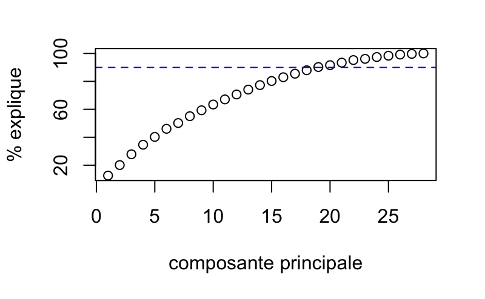

```r
#ACP
pca <- data[,c(-29,-30)]
#number of principal components
vars <- apply(pca,2,var)
props <- vars / sum(vars)
plot(cumsum(props)*100,xlab='composante principale',ylab='% explique')
abline(h=90,col=4,lty=2)
```

La variance expliqué cumulé des composantes principales nous dit que 90% de l’information se concentre dans les 19 premières composantes. Ainsi nous pouvons réduire le modèle et selectionner uniquement les variables les plus significatives.